# Spatial distribution of 35 cetacean species off the coast of California

Mariano Viz

20/02/2021

**Data source:** Kaschner, K., Rius-Barile, J., Kesner-Reyes, K., Garilao, C., Kullander, S., Rees, T., & Froese, R. (2016). AquaMaps: Predicted range maps for aquatic species. Available at: https://www.aquamaps.org

## Summary

In this report, I explore the spatial distribution of 35 cetacean species off the coast of California. Species richness was obtained from the probability of occurrence, which, in turn, is determined based on the relative environmental suitability and species preferences for water temperature, depth, salinity, and distance to land. A threshold value for the probability of occurrence of 0.6 or higher was taken to classify species as “present”. Results are displayed on a static map of the California coast.

```r
#Rasterizing all layers together with `raster::stack()`:
ca_cet <- raster::stack(list.files(path = "ca_cetaceans", pattern = ".tif", full.names = TRUE))

#Check raster info and initial plot:
  #ca_cet
  #plot(ca_cet)
```

## Species richness of 35 cetacean species off the coast of California

```r
#Convert to data frame:
ca_cet_df <- raster::rasterToPoints(ca_cet) %>%
  as.data.frame()

#Data wrangling:
ca_cet_wrang <- ca_cet_df %>%
  pivot_longer(!1:2,  names_to = "species", values_to = "prob") %>%
  mutate(presence =  case_when(prob >= "0.6" ~ 1,
                               TRUE ~ 0)) #classify species as "present" based on threshold for the probability of occurrence of 0.6 or higher


#Counts species "present" (prob >= 0.6):
ca_cet_counts <- ca_cet_wrang %>%
  group_by(x,y) %>%
  summarise(counts = sum(presence))
#ca_cet_counts

#Download US map as sf (rnaturalearth package):
usa_sf <- ne_download(scale = "large", type = 'states', category = 'cultural', returnclass = 'sf')
```

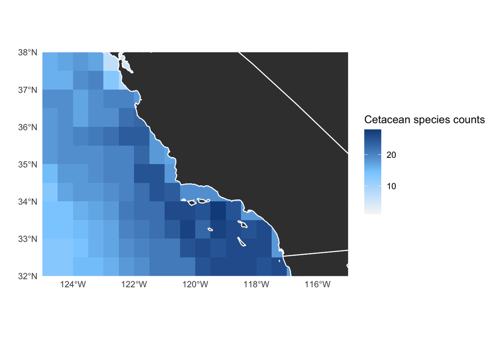

```r
#Plot (raster + sf):
ggplot() +
  geom_raster(data = ca_cet_counts, aes(x = x, y = y, fill = counts))+ #rater of species counts
  geom_sf(data = usa_sf, color = "white",  fill = "gray24")+ # US sf map ("large")
  coord_sf(xlim = c(-125, -115), ylim = c(32, 38), expand = FALSE) + #set boundaries of the map matching the raster
  scale_fill_gradientn(colors = c("gray97","skyblue1","dodgerblue4")) +
  theme_minimal() +
  labs(x = "", y = "",
       fill = "Cetacean species counts")
```

**Figure 1.** Species richness of 35 cetacean species off the coast of California. Presence of cetacean species was determined based on the probability of occurrence; a threshold value for the probability of occurrence of 0.6 or higher was taken to classify species as “present”. Spatial distribution of the color gradient, from light blue to dark blue, reflects the number of species categorized as “present” in each area. Data: Kaschner et al. (2016).